# XboxTA

Giovanni Aratico

2023-07-06

### GOAL:

- Analyze time series of achievement histories of a sample of profiles.
- Can we forecast user engagement?

## Create Files Directory

- Gets file directories of all CSVs to pull for analysis.
- Applies transformations for consistent format to dates of last scraped

```r
directory_df = create_file_directory()
directory_df = directory_transformations(directory_df)
```

## Read Manifests

- Load the full leaderboard of TA for exploratory data analysis.
- Read the full achievements manifest for later analysis.

```r
lb_df = read.csv("./data/leaderboard/leaderboard.csv")
lb_df = lb_feature_transformations(lb_df)
achievements_manifest = read.csv("./data/manifest/achievements_manifest.csv")
```

## Read Sample of Gamers

- We take a sample of 200 profiles using our file directory and order them.

```r
set.seed(196)
rnd_gamer_sample = sample_random_gamers(200, directory_df = directory_df)
rnd_gamer_sample = lapply(rnd_gamer_sample, function(x) x[order(rnd_gamer_sample[[3]])])
```

### Achievement Transformations

- Removes character entries for achievement earned.
- Formats date and adds formatted columns for month, day of year and isoweek.
- Creates column for tracking weekend / weekday

```r
rnd_gamer_sample[[1]] = achievement_transform_today(rnd_gamer_sample[[1]], directory_df)
rnd_gamer_sample[[1]] = achievement_transform_yesterday(rnd_gamer_sample[[1]], directory_df)
rnd_gamer_sample[[1]] = achievement_transform_drop_offline(rnd_gamer_sample[[1]])
rnd_gamer_sample[[1]] = achievement_transform_format_dates(rnd_gamer_sample[[1]])
rnd_gamer_sample[[1]] = achievement_transform_extract_dates(rnd_gamer_sample[[1]])
```

# Game Transformations

- Removes entries with unattainable values.
- Extracts hours and minutes and splits columns
- Splits app hours from game hours

```r
rnd_gamer_sample[[2]] = games_transform_drop_bad_titles(rnd_gamer_sample[[2]])
rnd_gamer_sample[[2]] = games_transform_hours(rnd_gamer_sample[[2]])
```

# Metrics Preprocessing (Total)

- Outputs total observations
- Processes the metrics data frame for all profiles

```r
print(paste("TOTAL OBSERVATIONS:", get_total_observations(rnd_gamer_sample[[1]])))
```

```
## [1] "TOTAL OBSERVATIONS: 401773"
```

```r
metrics_df = process_metrics_df(rnd_gamer_sample, directory_df)
```

# Frequency Data Preprocessing

- Intermediate Step to analyze each profile in the sample later.

```r
frequency_dfs = achievement_calculate_frequencies(rnd_gamer_sample)
frequency_combined_df = bind_rows(frequency_dfs, .id = "data_frame_id")
frequency_combined_df$data_frame_id = as.numeric(frequency_combined_df$data_frame_id)
```

```r
da_df = calculate_daily_achievements(frequency_combined_df)
da_df = da_fill_dates(da_df)

da_profiles = da_split_by_profile(da_df)
da_profiles = da_profiles_set_churn(da_profiles)
```

```
## [1] "PROFILE: 150 DROPPED (All NA values)"
```

```r
da_profiles = da_profiles_set_days_existence(da_profiles)
da_profiles = calculate_daily_lt_eir(da_profiles)
da_profiles = calculate_weekly_eir_all(da_profiles)
da_profiles = calculate_monthly_eir_all(da_profiles)
```

# Leaderboard Frequency Plots

- Outputs the frequency of score ranges for the entirety of the leaderboard

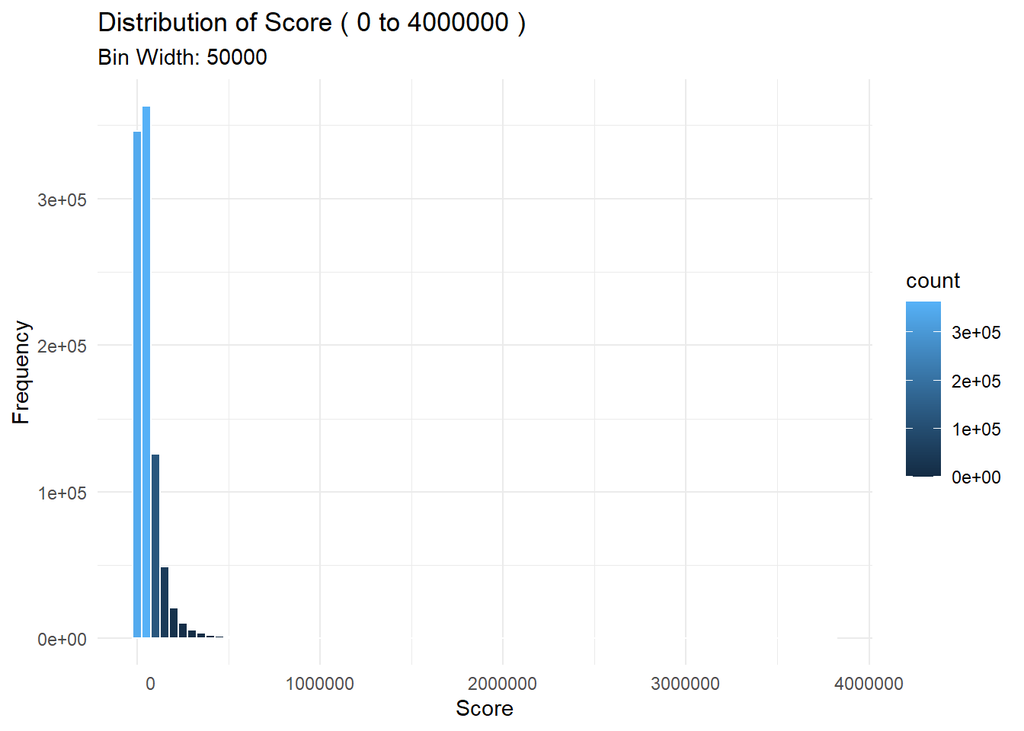

```r
plot_lb_range(lb_df, "Score", 0, 4000000, 50000, 1000000)
```

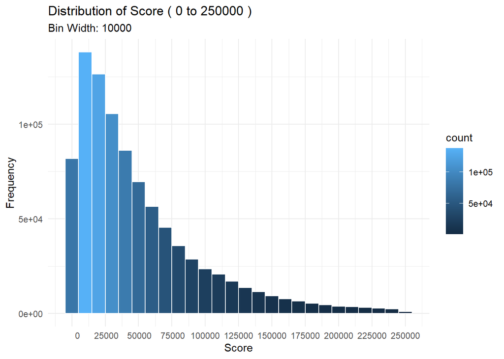

```r
plot_lb_range(lb_df, "Score", 0, 250000, 10000, 25000)
```

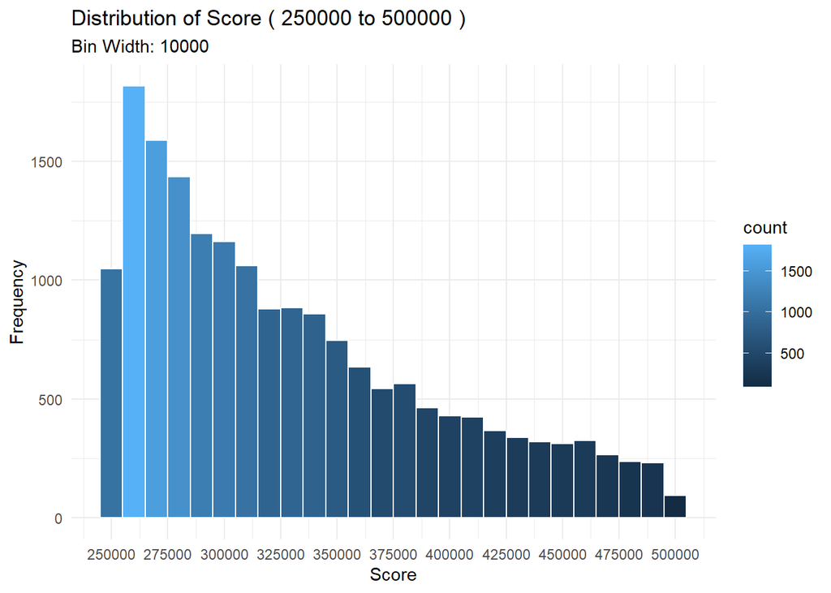

```r
plot_lb_range(lb_df, "Score", 250000, 500000, 10000, 25000)
```

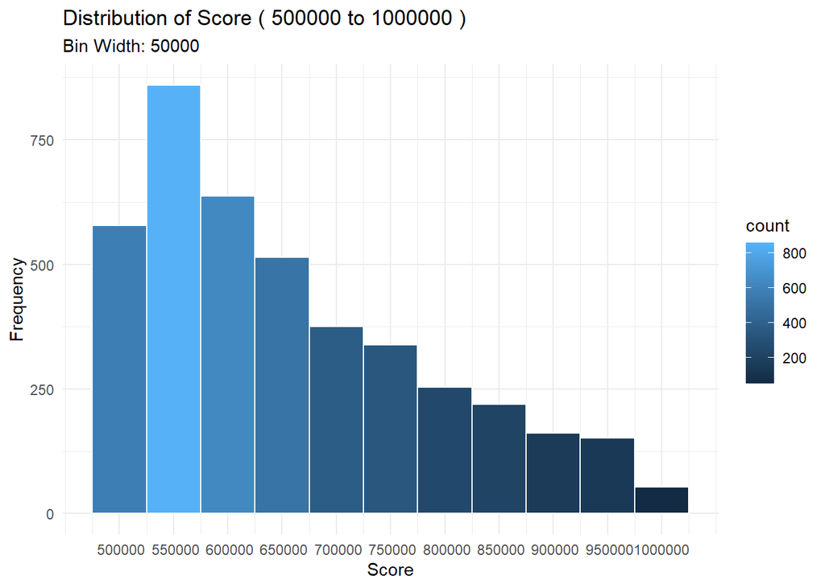

```r
plot_lb_range(lb_df, "Score", 500000, 1000000, 50000, 50000)
```

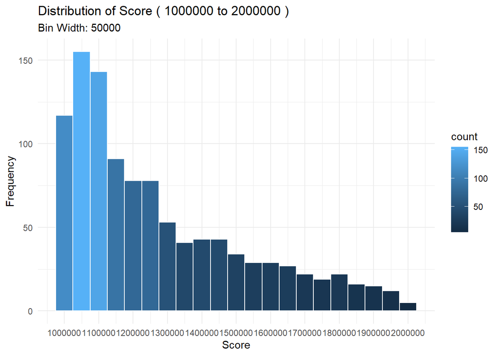

```r
plot_lb_range(lb_df, "Score", 1000000, 2000000, 50000, 100000)
```

**Note:** This Shiny app won’t display in the self-contained HTML file. To interact with the app, you can run the RMD document in an R Markdown viewer or in the RStudio IDE.

# Churned @ 365 Days Histogram

- Most users from this sample, approx. 75% not churned by this definition

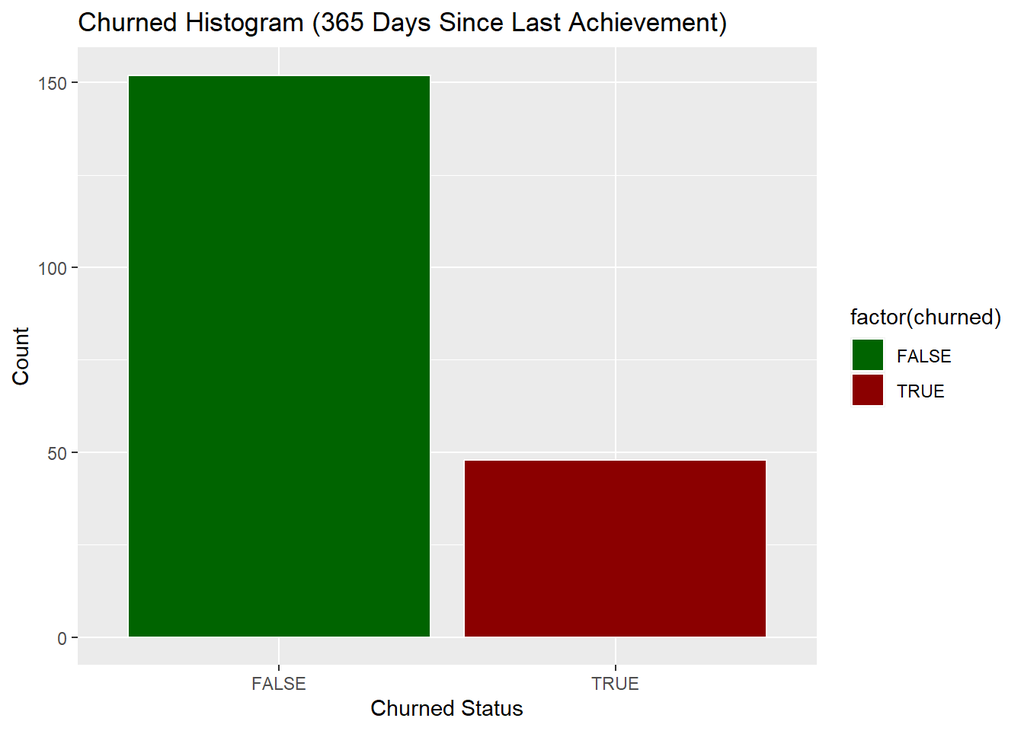

```r
# Plot histogram of churned with different colors for TRUE, FALSE, and NA
ggplot(metrics_df, aes(x = churned, fill = factor(churned))) +
  geom_bar(color = "white") +
  scale_fill_manual(values = c("darkgreen", "darkred", "gray")) +
  labs(title = "Churned Histogram (365 Days Since Last Achievement)", x = "Churned Status", y = "Count")
```

# Longest Streak Histogram

- Most users have 4 or 5 days as their longest streak.
- This sample approximates a roughly normal distribution.

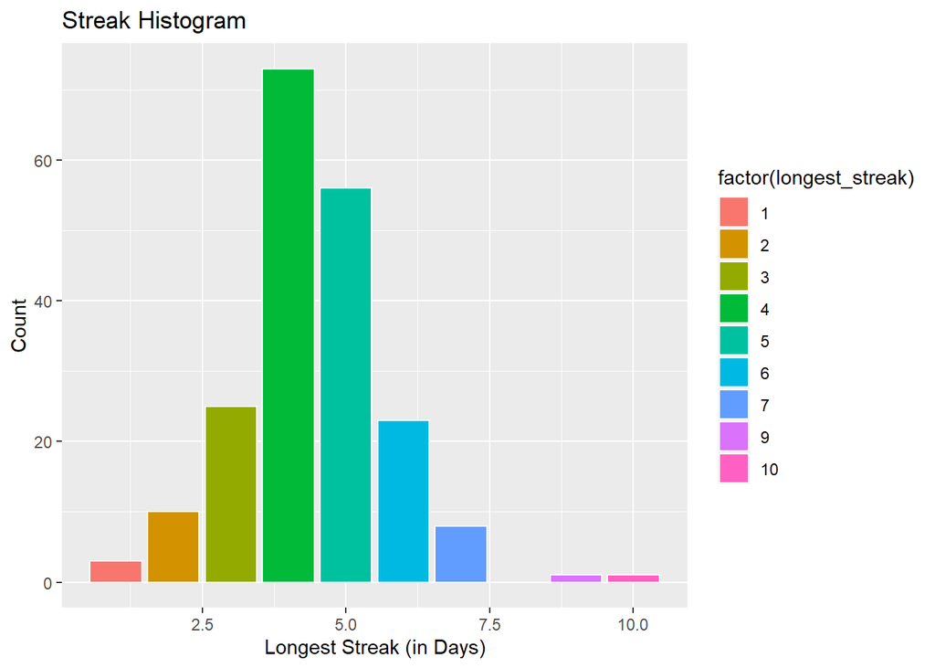

```r
ggplot(metrics_df, aes(x = longest_streak, fill = factor(longest_streak))) +
  geom_bar(color = "white") +
  labs(title = "Streak Histogram", x = "Longest Streak (in Days)", y = "Count")
```